# Homework 1

## Problem 1

### 1.1

Read `health.csv` and check basic information:

```r
health <- read.csv("health.csv")
head(health)
```

|  | country | age | sex | height | weight | hungry | fruit | vegetables | teeth | hands_eating | hands_toilet | hands_soap | sample_weight | bmi |
| --- | --- | --- | --- | --- | --- | --- | --- | --- | --- | --- | --- | --- | --- | --- |
| 1 | aeh | 16+ | Male | 1.70 | 58 | Sometimes | <1 | 1 | 0 | Always | Always | Sometimes | 30.3289 | 20.06920 |
| 2 | aeh | 16+ | Male | 1.72 | 85 | Never | <1 | <1 | 2 | Always | Most of the time | Always | 30.3289 | 28.73175 |
| 3 | aeh | 16+ | Male | NA | NA | Never | <1 | 1 | 3 | Always | Always | Always | 30.3289 | NA |
| 4 | aeh | 16+ | Male | 1.65 | 51 | Never | <1 | 2 | 1 | Always | Always | Always | 30.3289 | 18.73278 |
| 5 | aeh | 15 | Male | 1.72 | 52 | Never | <1 | <1 | <1 | Always | Always | Most of the time | 30.3289 | 17.57707 |
| 6 | aeh | 16+ | Male | 1.71 | 88 | Rarely | <1 | <1 | <1 | Always | Always | Always | 30.3289 | 30.09473 |

```r
str(health)
```

```
'data.frame':   24662 obs. of  14 variables:
 $ country      : Factor w/ 3 levels "aeh","pih","ugh": 1 1 1 1 1 1 1 1 1 1 ...
 $ age          : Factor w/ 6 levels "11-","12","13",..: 6 6 6 6 5 6 6 6 6 6 ...
 $ sex          : Factor w/ 2 levels "Female","Male": 2 2 2 2 2 2 2 2 2 2 ...
 $ height       : num  1.7 1.72 NA 1.65 1.72 1.71 1.63 1.59 1.67 1.74 ...
 $ weight       : int  58 85 NA 51 52 88 70 56 125 54 ...
 $ hungry       : Factor w/ 5 levels "Always","Most of the time",..: 5 3 3 3 3 4 1 4 3 3 ...
 $ fruit        : Factor w/ 7 levels "0","1","<1","2",..: 3 3 3 3 3 3 4 3 4 4 ...
 $ vegetables   : Factor w/ 7 levels "0","1","<1","2",..: 2 3 2 4 3 3 3 2 2 4 ...
 $ teeth        : Factor w/ 6 levels "0","1","<1","2",..: 1 4 5 2 3 3 1 2 1 1 ...
 $ hands_eating : Factor w/ 5 levels "Always","Most of the time",..: 1 1 1 1 1 1 1 1 1 1 ...
 $ hands_toilet : Factor w/ 5 levels "Always","Most of the time",..: 1 2 1 1 1 1 1 1 1 1 ...
 $ hands_soap   : Factor w/ 5 levels "Always","Most of the time",..: 5 1 1 1 2 1 1 1 1 1 ...
 $ sample_weight: num  30.3 30.3 30.3 30.3 30.3 ...
 $ bmi          : num  20.1 28.7 NA 18.7 17.6 ...
```

### 1.2

12610 observations came from `Female`, and 11805 observations came from `Male`. There are also 247 missing values for the `sex` column.

```r
summary(health$sex)
```

```
Female   Male   NA's
 12610  11805    247
```

### 1.3

2187 missing values for the variable `height`.

```r
sum(is.na(health$height))
```

```
[1] 2187
```

For those non-missing values, 29 of them are larger than 1.875.

```r
sum(health$height>1.875, na.rm=TRUE)
```

```
[1] 29
```

### 1.4

Levels for the variable `hands_eating`:

```r
levels(health$hands_eating)
```

```
[1] "Always"           "Most of the time" "Never"            "Rarely"           "Sometimes"
```

Re-arrange the levels in the right order:

```r
health$hands_eating <- factor(health$hands_eating, levels=c("Always","Most of the time","Sometimes","Rarely","Never"))
levels(health$hands_eating)
```

```
[1] "Always"           "Most of the time" "Sometimes"        "Rarely"           "Never"
```

## Problem 2

### 2.1

Read `unemployment.txt`:

```r
unemployment <- read.table("unemployment.txt", head=TRUE, sep="|")
```

### 2.2

For the month of Aug-11, Imperical (CA), Yuma (AZ) and Salinas (PR) are three counties with the highest unemployment rates.

```r
library(dplyr)
countySortedByRate <- unemployment %>% filter(period == "Aug-11") %>% arrange(desc(rate)) %>% select(county,state, rate)
head(countySortedByRate, 3)
```

|  | county | state | rate |
| --- | --- | --- | --- |
| 1 | imperial | california | 32.5 |
| 2 | yuma | arizona | 30.7 |
| 3 | salinas | puerto rico | 26.2 |

Mckenzie, Slope and Williams are three counties with the lowest unemployment rates. All of them are in North Dakota.

```r
tail(countySortedByRate, 3)
```

|  | county | state | rate |
| --- | --- | --- | --- |
| 3218 | mckenzie | north dakota | 1.5 |
| 3219 | slope | north dakota | 1.4 |
| 3220 | williams | north dakota | 1.0 |

### 2.3

For the month of Aug-11, Whitley is the county in Indiana that has unemployment rate closest to the overall unemployment rate across the whole country.

```r
overallRate <- with(unemployment, sum(unemployed)/sum(as.numeric(civilian))*100)
unemployment %>% filter(period == "Aug-11", state_code == "IN") %>% mutate(diff = abs(rate-overallRate)) %>% filter(diff == min(diff)) %>% select(county, rate, diff)
```

| county | rate | diff |
| --- | --- | --- |
| whitley | 8.6 | 0.02852228 |

## Problem 3

### 3.1

Read `microarray.txt` into R, the dimension of the data frame is 6830 (genes) x 64 (cell lines).

```r
dat <- read.table("microarray.txt", head=TRUE)
dim(dat)
```

```
[1] 6830   64
```

### 3.2

`bvar` takes as inpute a data frame and a vector of row numbers and returns which of these rows has the largest standard deviation.

```r
bvar <- function(data, rows) {
  rowSd <- apply(data[rows,], 1, sd)
  rows[which.max(rowSd)]
}
bvar(dat, c(40, 50, 60))
```

```
[1] 50
```

### 3.3

Plot heatmap of samples with label LEUKEMIA or MELANOMA.

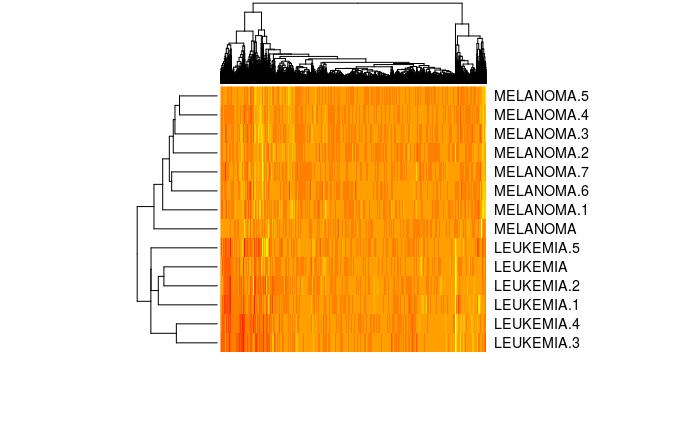

```r
dat <- dat %>% select(starts_with("LEUKEMIA"), starts_with("MELANOMA"))
heatmap(t(as.matrix(dat)), labCol=FALSE, scale="none")
```

### 3.4

Replot the heatmap in red-green color system.

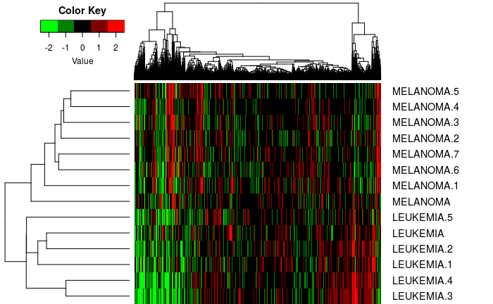

```r
library("gplots")
heatmap.2(t(as.matrix(dat)), col=greenred, breaks=-2.5:2.5, labCol=FALSE, margins=c(0,10), scale="none", trace="none", density.info="none")
```